# Autism_Mapping_Plus_Analysis

## Pathway analysis (enrichment of gene categories for 3'UTR lengthening autism vs. control)

```r
score <- eff_list[ ,8] # select layer 2/3 neurons as score
names(score) <- str_split(names(score), '_', simplify = TRUE)[ ,1] # remove the transcript level
score <- sort(score, decreasing = TRUE) # order the score
plot(score)

# compute the pathway enrichment with Reactome PA
require(ReactomePA)
set.seed(101)
pw <- gsePathway( score, minGSSize = 10, organism = 'human', pvalueCutoff = .1, nPerm = 1000)
pw@result
```

> Let's plot significant pathways! (for layer 2/3 neurons and astroyptes, respectively)

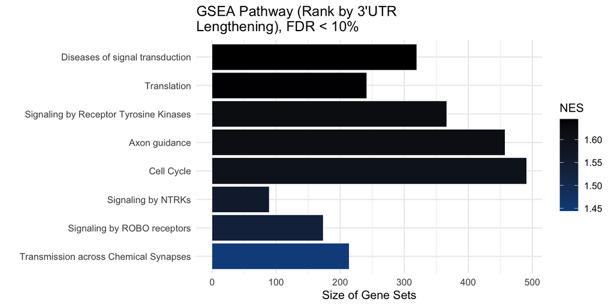

```r
# load the pre-compiled files
load(file = 'asd_pathway.rda')

# ... plot it
ggplot( path_l23_tbl, aes(y = setSize, x = Description, fill = NES ) ) + geom_col() + coord_flip() +
             ggtitle("GSEA Pathway (Rank by 3'UTR\nLengthening), FDR < 10%") + theme_minimal() +
             labs(x = '', y = 'Size of Gene Sets') +
             scale_fill_gradient(low = 'dodgerblue4', high = 'black')
```

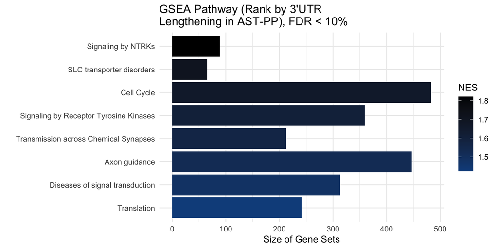

```r
ggplot( path_astpp_tbl, aes(y = setSize, x = Description, fill = NES ) ) + geom_col() + coord_flip() +
             ggtitle("GSEA Pathway (Rank by 3'UTR\nLengthening in AST-PP), FDR < 10%") + theme_minimal() +
             labs(x = '', y = 'Size of Gene Sets') +
             scale_fill_gradient(low = 'dodgerblue4', high = 'black')
```

## Search for enriched motifs in 3'UTRs which are longer in autism patients compared to the control cohort

> Prepare the input for the homer2 tool

```r
# Feature selection
                                                                                             # UTR length greather than 500 bp
fgd <- sort( lm_list$`L2/3`[ef_diff[ ,'L2/3'] > 0 & sapply(utr_seq[rownames(ef_list)], nchar) > 500 ] )[1:500] # 500 genes with highest lengthening effect
bck <- sort( lm_list$`L2/3`[ef_diff[ ,'L2/3'] < 0 & sapply(utr_seq[rownames(ef_list)], nchar) > 500 ] )[1:500]

require(Biostrings)                                        # distal parts of the UTRs (last 250 bps)
bck_motif <- mapply( function(x, y){  substring(x, nchar(x) - 250, nchar(x)  )  }, x = utr_seq[names(bck)] )
fgd_motif <- mapply( function(x, y){  substring(x, nchar(x) - 250, nchar(x)  )  }, x = utr_seq[names(fgd)] )
# save as fasta for the homer2 tool as input
x_bck <- DNAStringSet(bck_motif)
writeXStringSet(x_bck, filepath = 'bck_motif.fasta')
x_set <- DNAStringSet(fgd_motif)
writeXStringSet(x_set, filepath = 'fgd_motif.fasta')
```

> Run homer2 (de-novo motif analysis)

```bash
 cd /Volumes/g381-daten2/goepferich/3UTR_REANALYSIS_2019/autistic_human_brain
 export PATH=$PATH:/Users/manuelgopferich/Downloads/bin
 homer2 denovo -strand + -len 7 -i fgd_motif.fasta -b bck_motif.fasta > motif_homer2.txt
```

> First have a look at all results (25), then plot the top 4 results (as in the paper)

```r
# read the homer2 result into R using the marge package
hout <- marge::read_motif("motif_homer2.txt")
hout[ ,1:4]
```

| consensus | motif_name | log_odds_detection | motif_id |
| --- | --- | --- | --- |
| TAAAGTA | 1-TAAAGTA | 5.764698 | 1 |
| TTTTTGT | 2-TTTTTGT | 6.388914 | 2 |
| GTGTAGC | 3-GTGTAGC | 5.739739 | 3 |
| GTTGTAA | 4-GTTGTAA | 6.023058 | 4 |
| CTACCGA | 5-CTACCGA | 6.550770 | 5 |
| TGGTACG | 6-TGGTACG | 6.913258 | 6 |
| ATACACT | 7-ATACACT | 6.441839 | 7 |
| TGCATTA | 8-TGCATTA | 7.281175 | 8 |
| ATTTTAG | 9-ATTTTAG | 5.348888 | 9 |
| ACCGTTT | 10-ACCGTTT | 2.159026 | 10 |

[output cut: 15 more lines]

```r
require(ggseqlogo)
```

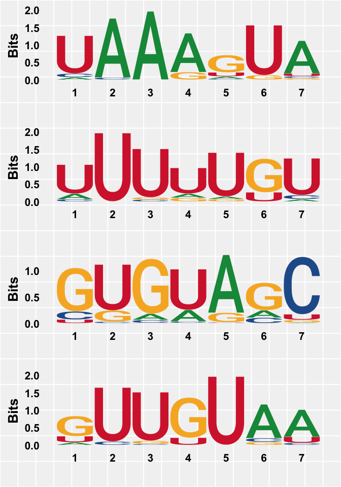

```r
m1 <- t(as.matrix(hout$motif_pwm[[1]]))
rownames(m1) <- c('A', 'C', 'G', 'U') # for RNA T --> U

m2 <- t(as.matrix(hout$motif_pwm[[2]]))
rownames(m2) <- c('A', 'C', 'G', 'U')

m3 <- t(as.matrix(hout$motif_pwm[[3]]))
rownames(m3) <- c('A', 'C', 'G', 'U')

m4 <- t(as.matrix(hout$motif_pwm[[4]]))
rownames(m4) <- c('A', 'C', 'G', 'U')

gg_motif1 <- ggseqlogo(m1) + theme(text = element_text(face = 'bold', size = 10))
gg_motif2 <- ggseqlogo(m2) + theme(text = element_text(face = 'bold', size = 10))
gg_motif3 <- ggseqlogo(m3) + theme(text = element_text(face = 'bold', size = 10))
gg_motif4 <- ggseqlogo(m4) + theme(text = element_text(face = 'bold', size = 10))

gg_motif_homer  <- arrangeGrob(gg_motif1, gg_motif2, gg_motif3, gg_motif4, ncol = 1)
plot(gg_motif_homer )
```

> To confirm *in silico* that there is an effect of the CPE motif one can assess directly the location of the motif

```r
# load the pre-compiled file
load(file = 'cpe_l23_distr_tbl.rda')

# Genes where clustered whether they bear the CPE motif in the distal part of the 3'UTR
# This poses the reverse analysi to the homer2 analysis (This is a supervised approach)

# conduct a chi-square test
chisq.test( matrix(cpe_l23_distr_tbl$cts, 3, 2) )
```

```
##
##  Pearson's Chi-squared test
##
## data:  matrix(cpe_l23_distr_tbl$cts, 3, 2)
## X-squared = 25.709, df = 2, p-value = 2.615e-06
```

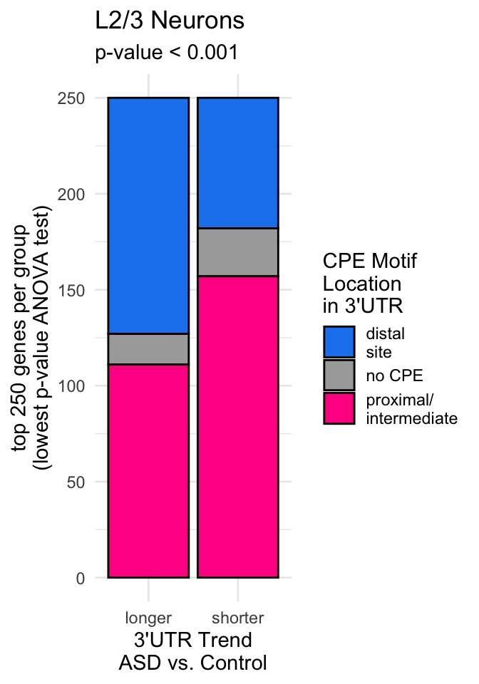

```r
# plot it
       ggplot(cpe_l23_distr_tbl , aes(x = grp, y = cts, fill = cpe )) +
       geom_col(color = 'black') +
       theme_minimal() +
       scale_fill_manual(values = c('dodgerblue2', 'darkgrey', 'deeppink')) +
       labs(fill = "CPE Motif\nLocation\nin 3'UTR",
            x = "3'UTR Trend\nASD vs. Control", y = "top 250 genes per group\n(lowest p-value ANOVA test)",
            subtitle = 'p-value < 0.001') +
      ggtitle('L2/3 Neurons')
```

> CONCLUSION: Also in the reverse/supervised analysis the distal parts of 3'UTRs getting longer inautism vs. control are enriched for the CPE motif.